# sde-lecture

This lecture is about the overlap between gradient descent and Markov chain Monte Carlo. It consists of four section, each of which is largely based on the following material:

- [Gradient flows](https://francisbach.com/gradient-flows/) and [Rethinking SGD noise](https://francisbach.com/rethinking-sgd-noise/)
- [Bayesian Learning via Stochastic Gradient Langevin Dynamics](https://www.stats.ox.ac.uk/~teh/research/compstats/WelTeh2011a.pdf)
- [A Complete Recipe for Stochastic Gradient MCMC](https://arxiv.org/pdf/1506.04696.pdf)

This tutorial additionally refers to

- [Stochastic quasi-Newton Langevin Monte Carlo paper](https://arxiv.org/pdf/1602.03442.pdf)
- [A tutorial introduction to Monte Carlo methods, Markov chain Monte Carlo and particle filtering](https://www.cmpe.boun.edu.tr/~cemgil/Courses/cmpe548/cmpe58n-lecture-notes.pdf)
- [MCMC using Hamiltonian dynamics](https://arxiv.org/pdf/1206.1901.pdf)
- [MCMC demo](http://chi-feng.github.io/mcmc-demo/app.html?algorithm=HamiltonianMC&target=banana)

Each section contains an interactive demo or code snippet. We will have a short break after Section 2, during which you are encouraged to play around with these.

Let's get started with importing the necessary libraries.

```python
%load_ext autoreload
%autoreload 2
!pip install torch numpy scipy matplotlib

import importlib, torch, pickle, os, sys, copy, numpy as np

import matplotlib.pyplot as plt
from matplotlib import animation
os.environ['KMP_DUPLICATE_LIB_OK']='True'
%matplotlib notebook
plt.rcParams.update({
    "text.usetex": True,
    "font.family": "serif",
    "font.serif": ["Palatino"],
})

import torch
import torch.nn as nn
device = torch.device('cuda' if torch.cuda.is_available() else 'cpu')

from utilities import forward_simulate
from anim_utils import plot_opt_animation
```

## 1. Ordinary Differential Equations (ODEs) and Gradient Descent (GD)

### 1.1. Ordinary Differential Equations (ODEs)

Ordinary differential equations involve an independent variable, its functions and derivatives of these functions. Formally,

\begin{equation} \dot{x}(t) = \frac{dx(t)}{dt} = \lim_{\Delta t \rightarrow 0} \frac{ x(t + \Delta t) - x(t)}{\Delta t} = f(x(t),t), \end{equation}

where

- $t$ denotes time (or any other independent variable)
- $x(t) \in \mathcal{X} \in \mathbb{R}^d$ is the state vector at time $t$ (thus dependent variable)
- $\dot{x}(t) \in \dot{\mathcal{X}} \in \mathbb{R}^d$ is the first order time derivative of $x(t)$
- $f : \mathcal{X} \times \mathbb{R}_+ \rightarrow \dot{\mathcal{X}}$ is the vector-valued and continuous (time) differential function describing the system's evolution over time with $\mathbb{R}_+$ denoting non-negative real numbers.

We often refer to $f$ as *vector field* or *right hand side*. Informally speaking, $f$ tells "how much the state $x(t)$ would change with an infinitisemal change in $t$".

An "ODE state solution" $x(t)$ at time $t\in \mathbb{R}_+$ is given by \begin{equation} x(t) = x_0 + \int_0^t f(x_\tau)~d\tau, \end{equation} where $x_0$ denotes the initial value and $\tau \in \mathbb{R}_+$ is an auxiliary time variable. Given an initial value $x_0$ and a set of time points $\{t_0,t_1,\ldots,t_N\}$, we are often interested in state solutions $x_{0:N}\equiv\{x(t_0),x(t_1),\ldots,x(t_N)\}$

#### Numerical Integration

Above integral has a tractable form only for very trivial differential functions (recall the integration rules from high school). This is why we almost always resort to *numerical simulation*.

More formally, we consider the rate of change of $x$ around $t$: \begin{equation} x(t+\delta) = x(t) + \delta f(x(t)) + o(||\delta||). \end{equation}

Assuming we can live with the smaller error term, we obtain the following recursive (and discrete) algorithm to compute state solutions: \begin{equation} x(t+\delta) = x(t) + \delta f(x(t)). \end{equation}

### 1.2. Gradient Descent (GD)

Gradient descent (GD) is by far the most commonly used optimization technique in deep learning era. Here, we restrict ourself to maximum a-posteriori estimation problem. Let's first set up the notation:

- $\theta$ denotes a parameter vector
- $p(\theta)$ is our prior belief on the parameters
- $p(x\mid\theta)$ denotes the likelihood
- $X \equiv \{ x_n \}_{n=1}^N$ is the dataset

Posterior distribution is proportional to $$ p(\theta \mid X) \propto \prod_n p(x_n \mid \theta) p(\theta).$$

In practice, MAP estimation task translates to minimizing minus log posterior density: $$ \min_\theta~~ g(\theta) \equiv -\log p(\theta \mid X) = -\log p(\theta) - \sum_n \log p(x_n \mid \theta)$$

Gradient descent (GD) aims to minimize a function by taking *small* steps in the direction of steepest descent, which is given by the gradient vector. More concretely, it iterates the following update equation:

\begin{equation} \theta_{n+1} = \theta_{n} - \delta \nabla g(\theta_{n}), \end{equation}

where $n$ denotes the current step, $\theta_{n}$ is the current iterate, and $\delta>0$ is the learning rate.

#### From GD to ODEs

Assuming that each GD update step takes "$\delta$ units", i.e. $\theta_{n} \equiv \theta(\delta n)$, and defining $t \equiv \delta n$, we obtain the following:

\begin{equation} \theta(t+\delta) = \theta(t) - \delta \nabla g(\theta(t)). \end{equation}

Comparing this with the last equation in "numerical integration" section, we conclude that

**GD is an ODE system in which vector field is given by the gradient of the optimized function.**

Below we contrast gradient descent and ODE flow.

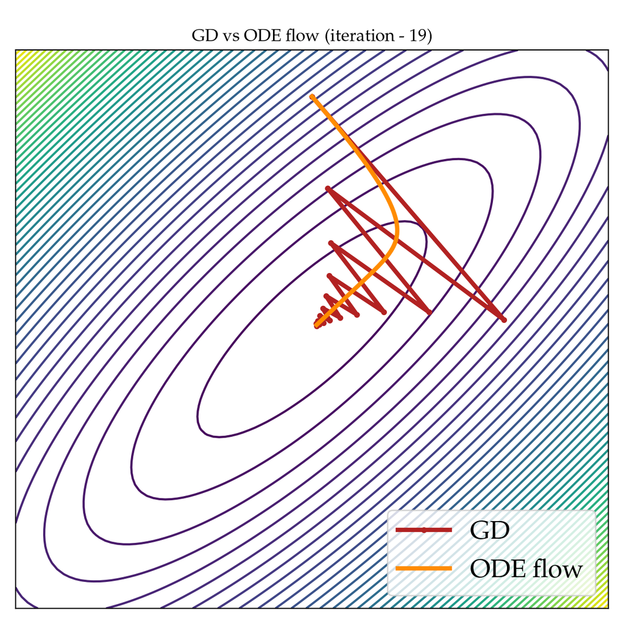

```python
# the loss function
m    = torch.tensor([0.0,0.0])
std  = torch.tensor([[1.0,0.81],[0.81,1.0]])
dist = torch.distributions.MultivariateNormal(m,std)

def loss_fnc(x):
    return -dist.log_prob(x)

# GD and ODE flow simulations
def solve_systems(gd_lr=0.33, num_iter=30, num_euler=50):
    x0_  = torch.tensor([0.,5.]).to(torch.float32)
    xpar = torch.nn.Parameter(x0_.clone()) # 1,P

    # gradient descent solution
    opt = torch.optim.SGD([xpar],lr=gd_lr)
    gd_loss_trace = []
    for i in range(num_iter):
        gd_loss_trace.append(xpar.detach().clone())
        opt.zero_grad()
        loss = loss_fnc(xpar)
        loss.backward()
        opt.step()
    gd_loss_trace = torch.stack(gd_loss_trace).numpy()

    # ode solution
    dt = gd_lr / num_euler
    ts = torch.arange(num_euler*num_iter) * dt
    x0 = torch.nn.Parameter(x0_.clone())
    def odef(t,x):
        f = -loss_fnc(x)
        grad = torch.autograd.grad(f,x)[0]
        return grad
    ode_loss_trace = forward_simulate(odef, x0, ts, method='euler') # T,P
    ode_loss_trace = ode_loss_trace.detach().numpy()

    return gd_loss_trace,ode_loss_trace


gd_loss_trace, ode_loss_trace = solve_systems()

anim = plot_opt_animation(loss_fnc, gd_loss_trace, ode_loss_trace)
```

## 2. Are Stochastic Gradient Descent (SGD) and Stochastic Differential Equations (SDEs) Likewise Related?

So far, we have seen that ODEs and GD are one of a kind. Here, we naturally question wheter SDEs and SGD are likewise related or not. Before discussing this in detail, we describe stochastic gradient descent (SGD), which is nothing other than GD in which the likelihood is evaluated on a minibatch.

Say $\Omega_t \subset \{1,\ldots,N\}$ is a random data subsample at iteration $t$. The optimization task at this iteration becomes

$$ \min_{\theta_t}~~ -\log p(\theta_t) - \frac{N}{|\Omega_t|} \sum_{n \in \Omega} \log p(x_n \mid \theta_t).$$

It simply implies the following parameter update equation:

$$ \theta_{t+1} = \theta_t + \frac{\epsilon_t}{2} \left( \nabla \log p(\theta_t) + \frac{N}{|\Omega_t|} \sum_{n \in \Omega} \nabla \log p(x_n \mid \theta_t) \right), $$

where $\epsilon_t$ is the stepsize at iteration $t$ which satisfies

$$ \sum_{t=1}^\infty \epsilon_t = \infty \qquad\qquad \sum_{t=1}^\infty \epsilon_t^2 < \infty $$

ensuring that (i) the parameters will reach the high probability regions no matter how far away it was initialized to, and (ii) the parameters will converge to the mode instead of just bouncing around it.

### 2.1. A Naive Attempt

So okay, obviously above update equation heavily resembles gradient descent. Can we then show SDEs and SGD are related? Since we do know that SDEs involve a noise process, what if we simply add a white noise to the above equation? In particular, let's consider the following update equation:

$$ \theta_{t+1} = \theta_t + \frac{\epsilon_t}{2} \left( \nabla \log p(\theta_t) + \frac{N}{|\Omega_t|} \sum_{n \in \Omega} \nabla \log p(x_n \mid \theta_t) \right) + \frac{\epsilon_t}{2} \xi_t, \qquad \xi_t \sim \mathcal{N}(\xi_t; 0, I). $$

Techically, this equation converges to standard GD in the limit $\epsilon_t \rightarrow 0$. Informally speaking, this is because the variance of the noise term is proportional to $\epsilon_t^2$ whereas gradient update term scales with $\epsilon_t$. You can read the end of the blog post (https://francisbach.com/gradient-flows/) for a more rigorous argumentation.

### 2.2. Second Attempt

Okay, obviously the noise variance depended terribly on stepsize. What if we downscale the step size for the noise process? How about the following:

$$ \theta_{t+1} = \theta_t + \frac{\epsilon_t}{2} \left( \nabla \log p(\theta_t) + \frac{N}{|\Omega_t|} \sum_{n \in \Omega} \nabla \log p(x_n \mid \theta_t) \right) + \frac{\sqrt{\epsilon_t}}{2} \xi_t, \qquad \xi_t \sim \mathcal{N}(\xi_t; 0,I). $$

Inspecting carefully, this looks very much like the Euler-Maruyama discretization of an SDE. To simplify the analysis, let's consider a fixed step size $\epsilon_t \equiv \epsilon$ and re-write above equation:

Above equation is nothing but a discretization of the Langevin equation

$$ d\theta = - \frac{1}{2} \nabla U(\theta)dt + dB(t), \qquad U(\theta) \equiv - \log p(\theta \mid X ; \Omega)$$

where $B(t)$ is the standard Brownian motion. As covered previously, this SDE leads to the following stationary solution:

$$ p(\theta) \propto \exp(- U(\theta)) = p(\theta \mid X ; \Omega) $$

So, our second attempt indeed brought us to an SDE with an invariant measure. That means, simulating this process allows us to sample from the posterior distribution. In literature, this method is called Stochastic Gradient Langevin Dynamics (SGLD) discovered by Welling and Teh (https://www.stats.ox.ac.uk/~teh/research/compstats/WelTeh2011a.pdf).

**Disclaimer: We admit that the resulting continous-time process has a discontinuous drift term due to minibathces. Consequently, our "invariant measure" claim is wrong.**

#### MH correction

One detail that we omitted is that the discretization of the continuous-time process naturally incurs error. Importantly, the resulting sequence of samples $\{\theta_t \}_{t=1}^\infty$ would not follow the target distribution $\exp(- U(\theta))$. This can be addressed by performing so-called *Metropolis-Hestings correction*, which requires computing the posterior density on the entire dataset.

Similar to the SGD regime, the authors propose to reduce the step size $\epsilon \rightarrow 0$ as $t \rightarrow \infty$. Consequently the discretization error will diminish so that the MH rejection probability will approach 0 and we may simply ignore this step.

Below is a code snippet that implements the above idea. The optimization problem is based on Stochastic Quasi-Newton Langevin Monte Carlo paper (https://arxiv.org/pdf/1602.03442.pdf). You can play around with it by changing, e.g., (the skewness of) the loss function, step size, minibatch size, turning the algorithm into optimization, etc.

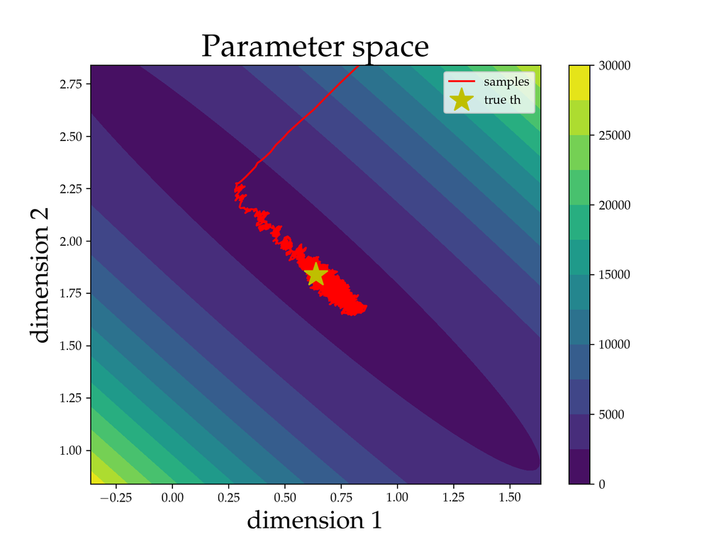

```python
# model: x_i|theta ~ N(x; A_i @ theta, sig_x)1
#        theta     ~ N(theta; 0, sig_theta)

###################################################
# dataset specs
N = 500  # num data points
d = 2    # data dim
sig_x = 0.1 # obs model parameter
sig_theta = torch.eye(d) # d,d

# data generation
A = torch.ones(N, d)/d + 0.1*torch.randn(N,d) # N,d
L = torch.linalg.cholesky(sig_theta) # d,d
theta = L @ torch.randn(d,1) # d,1
x     = A @ theta + np.sqrt(sig_x)*torch.randn(N,1)


###################################################
# optimization init
NSTEPS = 15000
theta0 = torch.Tensor([[2.,4.]]).T # initial parameters
prior_dist = torch.distributions.Normal(torch.zeros(d),torch.ones(d))

# stochastic MAP computation
def map_estimate(th, frac=0.1):
    # get a minibatch
    # th is [d,M]
    N_  = int(N*frac)
    idx = torch.randperm(N)[:N_]
    x_,A_ = x[idx],A[idx] # [N_,1], [N_,d]
    # MAP computation
    xhat  = A_ @ th # [N_,M]
    lhood = torch.distributions.Normal(xhat,sig_x).log_prob(x_) # [N_,M]
    lhood = lhood.sum(0) # [M]
    prior = prior_dist.log_prob(th.T) # [M,d]
    prior = prior.sum(1) # [M]
    return prior + 1/frac*lhood


# optimization loop
thetas,losses = [],[]
th = torch.nn.Parameter(theta0) # initial parameters
eta = 1e-5 # step size
for i in range(NSTEPS):
    thetas.append(th.detach().numpy().copy())
    MAP   = map_estimate(th, 0.1)
    grad  = torch.autograd.grad(MAP,th)[0]
    noise = torch.randn(d,1) * np.sqrt(2*eta)
    th.data = th.data + eta*grad/2 + noise
    losses.append(MAP.item())
thetas = np.array(thetas).squeeze(-1) # NSTEPS,d


###################################################
# visualizing the loss surface
Ngr = 100
w   = 1
xnp = np.linspace(theta[0]-w,theta[0]+w, Ngr)
ynp = np.linspace(theta[1]-w,theta[1]+w, Ngr)
X,Y = np.meshgrid(xnp, ynp)
XY  = torch.tensor(np.array([X.T.flatten(), Y.T.flatten()])).to(torch.float32)
map_XY = map_estimate(XY).reshape(Ngr,Ngr)
plt.figure(1,(8,6))
plt.contourf(X, Y, -map_XY, levels=10)
plt.colorbar()

# visualizing samples
plt.plot(thetas[:,0], thetas[:,1], color='r', label='samples')
plt.plot(theta[0,0].item(),theta[1,0].item(), 'y*', markersize=20, label='true th')
plt.xlim([theta[0]-w,theta[0]+w])
plt.ylim([theta[1]-w,theta[1]+w])
plt.title('Parameter space', fontsize=25)
plt.xlabel('dimension 1', fontsize=20)
plt.ylabel('dimension 2', fontsize=20)
plt.legend()
```

### 2.3. Completing the Picture with a Detour: SGD without Diffusion Process

So far, we have discarded an important aspect of our stochastic optimization setup. That is, we utilize randomly sampled minibatches for optimization, which inherently brings stochasticity to the system. [Rethinking SGD blog post](https://francisbach.com/rethinking-sgd-noise/) gives a very detailed analysis of SGD dynamics in over/under-parameterized NN regimes. Here, we repeat the main finding.

Given a dataset $X \equiv \{ x_n \}_{n=1}^N$ and loss function $h(x;\theta)^2$, we define the "batch loss" by \begin{equation} R(\theta) \equiv \frac{1}{N} \sum_i h(x_i;\theta)^2 \end{equation}

Note that this formulation could easily involve class labels as well, which we omit for ease in notation. Given a minibatch $\Omega_n \subset \{1,\ldots,N\}$ at iteration $n$, SGD update equation is given by

\begin{align} \theta_{n+1} &= \theta_{n} - \delta\epsilon_n(\theta_n) \\ &= \theta_{n} - \delta \nabla R(\theta_n) + \delta\epsilon_n(\theta_n). \end{align}

where the last term is defined by

\begin{equation} \epsilon_n(\theta_n) = \nabla R(\theta_n) - \sum_{i \in \Omega_n} \nabla h(x_i;\theta)^2. \end{equation}

It is shown that above SGD dynamics converges to the solution of the following SDE in the limit

\begin{equation} d\theta_t = b(\theta_t,t) + \sigma(\theta_t,t)dB(t) \end{equation}

where

- $B(t)$ is the standard Brownian motion
- Drift matches the gradient: $b(\theta_t,t) = - \nabla R(\theta_t)$
- Diffusion matches the gradient noise: $\sigma(\theta_t,t) \sigma(\theta_t,t)^T = \delta \mathbb{E} [\epsilon_n(\theta_n) \epsilon_n(\theta_n)^T ] $

Again, please see the blog post for more details.

## 3. A Quick Recap of Markov Chain Monte Carlo

In Markov Chain Monte Carlo methods, we sample from a Markov chain with transition density (or kernel) $K(\theta_n \mid \theta_{n−1})$ so that the sampling process $\{ \theta_n \}_{n=1}^\infty$ would converge to a distribution of interest $\pi(\theta)$. The transition rule is more explicitly given by

\begin{equation} p_n(\theta^\text{next}) = \int K(\theta^\text{next} \mid \theta) p_{n-1}(\theta) d\theta \end{equation}

Obviously, the process would not converge to $\pi(\theta)$ for all kernel choices. In the following, we describe two elegant ways of designing a Markov chain for a given target distribution.

### 3.1. Metropolis-Hastings Algorithm

For continuous Markov processes, an extremely simple procedure was defined by Metropolis and later extended by Hastings. The algorithm simply generates a *candidate* next state using a proposal density $q(\theta^\text{next} \mid \theta)$ that depends on the current sample $\theta$. The candidate is accepted with probability

\begin{equation} \alpha (\theta \rightarrow \theta^\text{next}) = \min \{ 1, \frac{q(\theta\mid \theta^\text{next}) \pi(\theta^\text{next})} {q(\theta^\text{next} \mid \theta)\pi(\theta)} \} \end{equation}

If the sample is not accepted, the chain stays put at the old location $\theta$. Below algorithm summarizes our description so far, taken kindly from [these lecture notes](https://www.cmpe.boun.edu.tr/~cemgil/Courses/cmpe548/cmpe58n-lecture-notes.pdf).

[figure not shown]

#### 3.1.1. Ergodicity

Valid MCMC samplers would converge to a unique invariant distribution regardless of the initial states. This only happens if the chain is *ergodic*, i.e., if it eventually visits the entire state space. Ergodicity is specified by the following:

- irreducibility, meaning that each state can be visited starting from each one (i.e. state transition diagram should be fully connected)
- aperiodicity, meaning that each state can be visited at any time n larger than some fixed number.

Please see the [lecture notes](https://www.cmpe.boun.edu.tr/~cemgil/Courses/cmpe548/cmpe58n-lecture-notes.pdf) for more details.

#### 3.1.2. Detailed balance

The stationary distribution of the Markov chain should satisfy \begin{equation} \pi(\theta^\text{next}) = \int K(\theta^\text{next} \mid \theta) \pi(\theta) dx. \end{equation} MH transitions satisfy a stronger condition known as *detailed balance* \begin{equation} K(\theta \mid \theta^\text{next} ) \pi(\theta^\text{next}) = K(\theta^\text{next} \mid \theta) \pi(\theta). \end{equation} We can prove that MH kernel indeed target the above stationary distribution by showing (i) detailed balance implies above stationary distribution, and (ii) MH acceptance ratio ensures the detailed balance condition.

Please, again, refer to the lecture notes for a derivation of the detailed balance condition.

#### 3.1.3. Random-walk MH Demo

Let's check this demo to see how "random-walk" MH proceeds if we set $q(\theta^\text{next} \mid \theta) \equiv \mathcal{N}( \theta^\text{next}; \theta, \sigma I)$: https://chi-feng.github.io/mcmc-demo/app.html?algorithm=RandomWalkMH&target=banana

### 3.2. Hamiltonian (Hybrid) Monte Carlo (HMC)

The main idea in HMC is to use Hamiltonian dynamics to produce distant proposals for the Metropolis-Hastings algorithm. By using the physical properties of the underlying system, we hope to generate transitions that span the entire state space variance and therefore eliminate the diffusive behaviour of random-walk proposals.

#### 3.2.1. Hamiltonian dynamics

Hamiltonian dynamics is a dynamical system governed by Hamilton's equations, which is commonly used to describe physical systems such as a planetary system or an electron in an electromagnetic field. As a simple example, we consider a ball that slides on a surface of varying height. The state of this system consists of the position of the ball, given by a variable $\theta \in \mathbb{R}^2$, and the momentum of the ballis given $p \in \mathbb{R}^2$. The potential energy $U(\theta)$ of the ball is proportional to the height of the surface at its current position. Its kinetic energy $K(p)=\frac{|p|^2}{2m}$, where $m$ is the mass of the ball. On a flat surface, the puck moves at a constant velocity, equal to $\frac{p}{m}$. If it encounters a rising slope, the ball’s momentum allows it to continue, with its kinetic energy decreasing and its potential energy increasing.

#### 3.2.2. Hamiltonian Monte Carlo

For Hamiltonian Monte Carlo, we usually use Hamiltonian functions written as follows:

\begin{align} H(\theta, p) = U(\theta) + K(p) \end{align}

Here, $U(\theta)$ is called the *potential energy*, and will be defined to be minus the log probability density of the distribution for $\theta$ that we wish to sample from:

\begin{align} U(\theta) \equiv -\log p(\theta \mid X). \end{align}

$K(p)$ is called the *kinetic energy*, and is usually defined as

\begin{align} K(p) \equiv \frac{p^T M^{-1} p}{2}, \end{align}

where $M$ is a symmetric, positive-definite “mass matrix”, which is typically diagonal, and is often a scalar multiple of the identity matrix. This form for $K(p)$ corresponds to minus the log probability density (plus a constant) of the zero-mean Gaussian distribution with covariance matrix $M$.

In HMC, the space for parameters $\theta \in \mathbb{R}^d$ is augmented with independent auxiliary variable $\mathbf{p} \in \mathbb{R}^d$ with density $p(\mathbf{p} ) = \mathcal{N}(\mathbf{p} \mid 0,M)$.

The partial derivatives of the Hamiltonian determine how $\theta$ and $p$ change over time according to Hamilton’s equations:

\begin{align} \frac{d\theta_i}{dt} = \frac{\partial H}{\partial p_i} = [M^{-1}p]_i, \qquad \frac{dp_i}{dt} = -\frac{\partial H}{\partial \theta_i} = \frac{\partial U}{\partial \theta_i} \end{align}

#### 3.2.3. Practical Algorithm

- **Step-1:**

New values for the momentum variables are randomly drawn from their Gaussian distribution $$p \sim \mathcal{N}(p ; 0,M)$$

- **Step-2:**

Hamiltonian dynamics are simulated for a MH proposal. For simulation, a reversible and volume-preserving numerical simulator (such as leap-frog method) is used. A proposed state $[\theta^\text{new},p^\text{new}])$ is accepted based on the following probability: $$ \min \{1, \exp(−H(\theta^\text{new},p^\text{new}) + H(\theta^\text{old},p^\text{old})\} \equiv \min \{1, \exp(−U(\theta^\text{new}) +U(\theta^\text{old}) − K(\theta^\text{new}) + K(\theta^\text{old})\} $$

#### 3.2.4. Demo

Let's check this demo to see how HMC draws samples on the same "banana" distribution that we sampled from using random-walk MH: https://chi-feng.github.io/mcmc-demo/app.html?algorithm=HamiltonianMC&target=banana

#### 3.2.5. Notes

**1.** Hamiltonian dynamics are reversible, i.e., mapping from a state $[\theta(t),p(t)]$ to another $[\theta(t+s),p(t+s)]$ is one-to-one, and hence has an inverse. This is important to satisfy the detailed balance condition defined above and thereby we show that HMC updates leave the desired distribution invariant.

**2.** By construction, Hamiltonian dynamics have zero divergence, implying volume preservation. Thanks to this, we do not need to account for any change in volume in the acceptance probability for Metropolis updates. If we proposed new states using some arbitrary, non-Hamiltonian, dynamics, we would need to compute the determinant of the Jacobian matrix for the mapping the dynamics defines, which might well be infeasible.

## 4. A Complete Recipe for Stochastic Gradient MCMC

Naturally, any proposal distribution $q(x^\text{new} \mid x)$ implies a different MCMC algorithm. How to choose a suitable MCMC algorithm and tune its hyper-parameters could be a tedious task. Furthermore, the target distribution $\pi(x)$ is typically the posterior density, whose computation involves a computationaly demanding sum over data points in large data sets. Consequently, we would like to build an MCMC method that can

- be applied to any problem off-the-shelf
- handle big data.

This is precisely what is done in the "Complete Recipe" paper (https://arxiv.org/pdf/1506.04696.pdf). There, the goal is to translate the task of sampling from the posterior distribution to simulating from a continuous dynamical system. This dynamical system defines a Markov transition kernel. More concretely, a differential equation is used used to map the state $z(t)$ at time t to a "next" state $z(t+h)$. One can then discuss the evolution of the distribution $p(z, t)$ given the dynamics (whether it converges or not, how fast it converges, etc). The invariant distribution of the dynamics can be analyzed by the Fokker-Planck equation for stochastic dynamics and we use the Liouville equation for deterministic dynamics.

### 4.1. Formal Framework

Now we turn to SDEs similar to previous section, this time more rigorous. Let's consider the following SDE

\begin{equation} dz = f(z)dt + \sqrt{2D(z)}dW(t) \end{equation}

where

- $f(z): \mathbb{R}^d \mapsto \mathbb{R}^d$ denotes the deterministic drift
- $D(z)$ is a positive semidefinite diffusion matrix
- $W(t)$ is a $d$-dimensional Wiener process.